#case study 1

```r
library(tidyverse)
library(VIM)
library(lattice)
library(DMwR)
library(mice)
```

```r
library(ggplot2)
library(ggthemes)
library(stringr)
library(class)
library(caret)
# Reading in the data and observing the first 6 observations for each data set
beers = read.csv("Beers.csv")
breweries = read.csv("Breweries.csv")
head(beers)
```

```
##                  Name Beer_ID   ABV IBU Brewery_id
## 1            Pub Beer    1436 0.050  NA        409
## 2         Devil's Cup    2265 0.066  NA        178
## 3 Rise of the Phoenix    2264 0.071  NA        178
## 4            Sinister    2263 0.090  NA        178
## 5       Sex and Candy    2262 0.075  NA        178
## 6        Black Exodus    2261 0.077  NA        178
##                            Style Ounces
## 1            American Pale Lager     12
## 2        American Pale Ale (APA)     12
## 3                   American IPA     12
## 4 American Double / Imperial IPA     12
## 5                   American IPA     12
## 6                  Oatmeal Stout     12
```

```r
head(breweries)
```

```
##   Brew_ID                      Name          City State
## 1       1        NorthGate Brewing    Minneapolis    MN
## 2       2 Against the Grain Brewery    Louisville    KY
## 3       3  Jack's Abby Craft Lagers    Framingham    MA
## 4       4 Mike Hess Brewing Company     San Diego    CA
## 5       5   Fort Point Beer Company San Francisco    CA
## 6       6     COAST Brewing Company    Charleston    SC
```

#question 1: how many breweries are present in each state?

```r
# We create a new data set where we group it by State and create a tally of of how many breweries are in each state, arrange it in descending order and show the 6  highest and lowest state frequencies
state_breweries <- breweries %>%
  group_by(State) %>%
  tally() %>%
  arrange(desc(n))
head(state_breweries)
```

```
## # A tibble: 6 x 2
##   State     n
##   <fct> <int>
## 1 " CO"    47
## 2 " CA"    39
## 3 " MI"    32
## 4 " OR"    29
## 5 " TX"    28
## 6 " PA"    25
```

```r
tail(state_breweries)
```

```
## # A tibble: 6 x 2
##   State     n
##   <fct> <int>
## 1 " MS"     2
## 2 " NV"     2
## 3 " DC"     1
## 4 " ND"     1
## 5 " SD"     1
## 6 " WV"     1
```

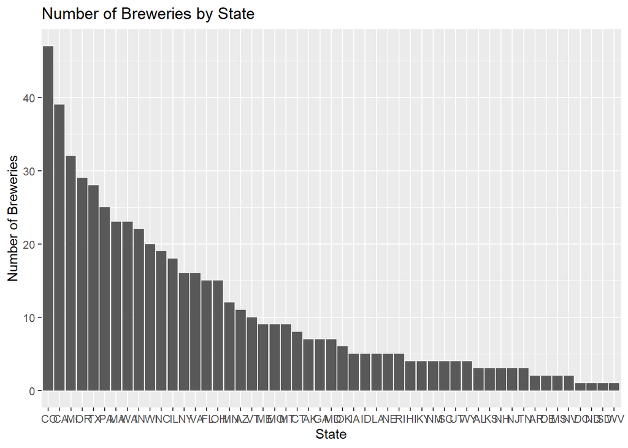

```r
#We create a bar graph of our previous results

state_breweries %>%
  ggplot(aes(x=reorder(State, -n), y=n)) +
  geom_bar(stat = "identity") +
  ggtitle("Number of Breweries by State") +
  xlab("State") +
  ylab("Number of Breweries")
```

#question 2: merge data

```r
#Merging the data sets with key Brew_ID and Brewery_id since they are the same but have different names
head(breweries)
```

```
##   Brew_ID                      Name          City State
## 1       1        NorthGate Brewing    Minneapolis    MN
## 2       2 Against the Grain Brewery    Louisville    KY
## 3       3  Jack's Abby Craft Lagers    Framingham    MA
## 4       4 Mike Hess Brewing Company     San Diego    CA
## 5       5   Fort Point Beer Company San Francisco    CA
## 6       6     COAST Brewing Company    Charleston    SC
```

```r
head(beers)
```

```
##                  Name Beer_ID   ABV IBU Brewery_id
## 1            Pub Beer    1436 0.050  NA        409
## 2         Devil's Cup    2265 0.066  NA        178
## 3 Rise of the Phoenix    2264 0.071  NA        178
## 4            Sinister    2263 0.090  NA        178
## 5       Sex and Candy    2262 0.075  NA        178
## 6        Black Exodus    2261 0.077  NA        178
##                            Style Ounces
## 1            American Pale Lager     12
## 2        American Pale Ale (APA)     12
## 3                   American IPA     12
## 4 American Double / Imperial IPA     12
## 5                   American IPA     12
## 6                  Oatmeal Stout     12
```

```r
beer_breweries = breweries %>%
  left_join(beers, by = c("Brew_ID" = "Brewery_id"))
names(beer_breweries) <- c("Brew_ID","Brewery_Name","City","State","Beer_Name", "Beer_ID","ABV","IBU","Style","Ounces")
head(beer_breweries)
```

```
##   Brew_ID       Brewery_Name        City State     Beer_Name Beer_ID   ABV
## 1       1 NorthGate Brewing  Minneapolis    MN  Get Together    2692 0.045
## 2       1 NorthGate Brewing  Minneapolis    MN Maggie's Leap    2691 0.049
## 3       1 NorthGate Brewing  Minneapolis    MN    Wall's End    2690 0.048
## 4       1 NorthGate Brewing  Minneapolis    MN       Pumpion    2689 0.060
## 5       1 NorthGate Brewing  Minneapolis    MN    Stronghold    2688 0.060
## 6       1 NorthGate Brewing  Minneapolis    MN   Parapet ESB    2687 0.056
##   IBU                               Style Ounces
## 1  50                        American IPA     16
## 2  26                  Milk / Sweet Stout     16
## 3  19                   English Brown Ale     16
## 4  38                         Pumpkin Ale     16
## 5  25                     American Porter     16
## 6  47 Extra Special / Strong Bitter (ESB)     16
```

#question 3: fix nas

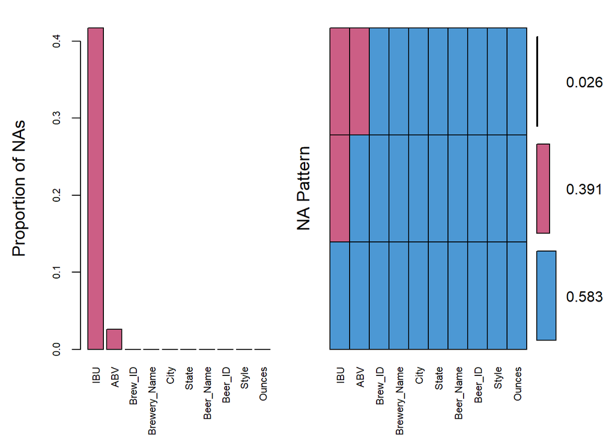

```
##
##  Variables sorted by number of missings:
##      Variable      Count
##           IBU 0.41701245
##           ABV 0.02572614
##       Brew_ID 0.00000000
##  Brewery_Name 0.00000000
##          City 0.00000000
##         State 0.00000000
##     Beer_Name 0.00000000
##       Beer_ID 0.00000000
##         Style 0.00000000
##        Ounces 0.00000000
```

```r
#Plot the NAs and look the proportion of NAs per column
beer_breweries_miss = aggr(beer_breweries, col=mdc(1:2), numbers=TRUE, sortVars=TRUE, labels=names(beer_breweries), cex.axis=.7, gap=3, ylab=c("Proportion of NAs","NA Pattern"))
```

```r
#Using Knn imputation as means to fill in the NA values
beer_breweries_impute <- knnImputation(beer_breweries)
beer_breweries <- beer_breweries_impute
```

#question 4: Compute the median alcohol content and international bitterness unit for each state. Plot a bar chart to compare.

Median alcohol content by state ranged from .04 ABV in UT to just over .06 ABV in DC. Below shows graphs of the median ABV by state.

```r
#median abv by state
state_abv = beer_breweries %>%
  group_by(State) %>%
  summarise(median = median(ABV, na.rm = TRUE))
head(state_abv)
```

```
## # A tibble: 6 x 2
##   State median
##   <fct>  <dbl>
## 1 " AK" 0.056
## 2 " AL" 0.06
## 3 " AR" 0.052
## 4 " AZ" 0.055
## 5 " CA" 0.058
## 6 " CO" 0.0609
```

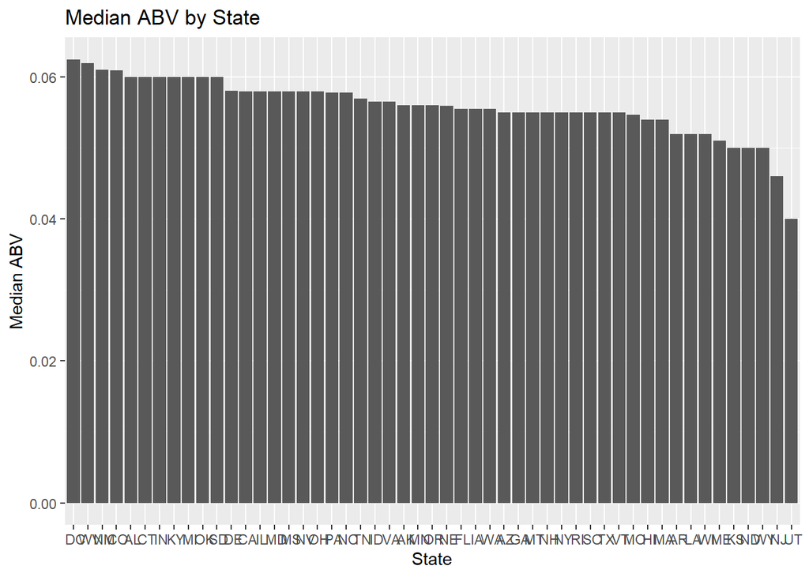

```r
#Bar plot of median abv by state
state_abv %>%
  ggplot(aes(x=reorder(State, -median), y=median)) +
  geom_bar(stat = "identity") +
  ggtitle("Median ABV by State") +
  xlab("State") +
  ylab("Median ABV")
```

```r
#median ibu by state
state_ibu = beer_breweries %>%
  group_by(State) %>%
  summarise(median = median(IBU, na.rm = TRUE))
head(state_ibu)
```

```
## # A tibble: 6 x 2
##   State median
##   <fct>  <dbl>
## 1 " AK"   26.0
## 2 " AL"   39.5
## 3 " AR"   22.1
## 4 " AZ"   22.2
## 5 " CA"   35
## 6 " CO"   33.0
```

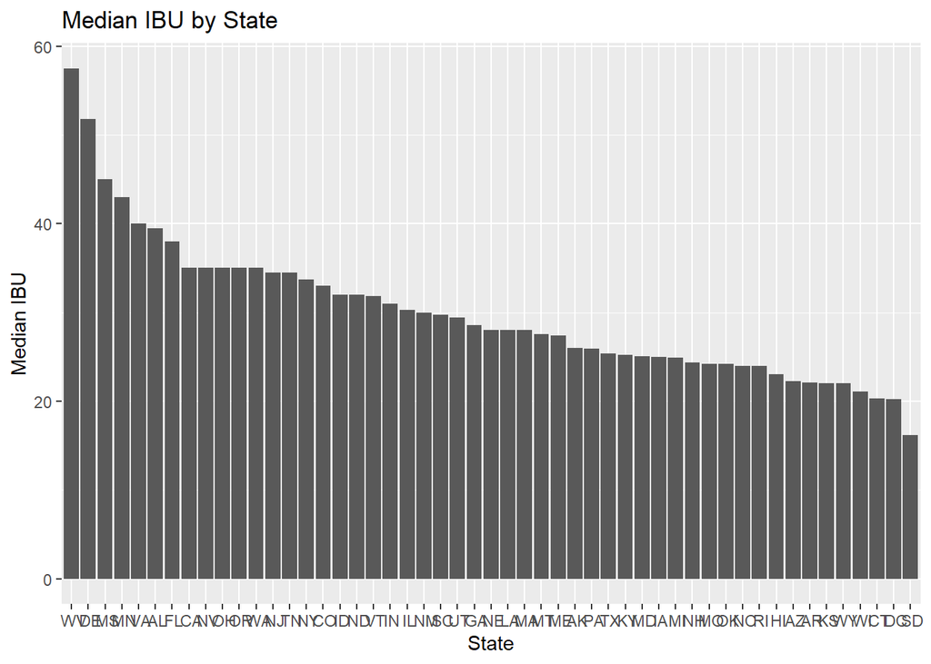

```r
#Bar plot of median IBU by state
state_ibu %>%
  ggplot(aes(x=reorder(State, -median), y=median)) +
  geom_bar(stat = "identity") +
  ggtitle("Median IBU by State") +
  xlab("State") +
  ylab("Median IBU")
```

#question 5: Which state has the maximum alcoholic (ABV) beer? Which state has the most bitter (IBU) beer?

The beer with most alcoholic content is the Lee Hill Quadruple Ale from Upslope Brewing Company in Colorado, at .128 ABV.

The beer with the most bitterness is Bitter Bitch Imperial IPA from Astoria Brewing Company in Oregon, at 138 IBU.

```r
#Create a dataset where we arrange the beer with highest ABV in descending order
#CO has the beer with the highest ABV
top_ABV <- beer_breweries %>%
  arrange(desc(ABV)) %>%
  top_n(10, ABV)
head(top_ABV[c("State", "Brewery_Name", "Beer_Name", "ABV")])
```

```
##   State              Brewery_Name
## 1    CO   Upslope Brewing Company
## 2    KY Against the Grain Brewery
## 3    IN   Tin Man Brewing Company
## 4    CO   Upslope Brewing Company
## 5    NY       Sixpoint Craft Ales
## 6    MI            Brewery Vivant
##                                              Beer_Name   ABV
## 1 Lee Hill Series Vol. 5 - Belgian Style Quadrupel Ale 0.128
## 2                                       London Balling 0.125
## 3                                                 Csar 0.120
## 4     Lee Hill Series Vol. 4 - Manhattan Style Rye Ale 0.104
## 5                                               4Beans 0.100
## 6                                 Wizard Burial Ground 0.099
```

```r
#Create a dataset where we arrange the beer with highest IBU in descending order
#OR has the beer with the highest IBU
top_IBU <- beer_breweries %>%
  arrange(desc(IBU)) %>%
  top_n(10, IBU)
head(top_IBU[c("State", "Brewery_Name", "Beer_Name", "IBU")])
```

```
##   State                       Brewery_Name                       Beer_Name
## 1    OR            Astoria Brewing Company       Bitter Bitch Imperial IPA
## 2    VA         Wolf Hills Brewing Company              Troopers Alley IPA
## 3    MA           Cape Ann Brewing Company                   Dead-Eye DIPA
## 4    OH Christian Moerlein Brewing Company Bay of Bengal Double IPA (2014)
## 5    MN              Surly Brewing Company                    Abrasive Ale
## 6    VT                      The Alchemist                    Heady Topper
##   IBU
## 1 138
## 2 135
## 3 130
## 4 126
## 5 120
## 6 120
```

```r
#Plot a histogram of the ABV distribution
summary(beer_breweries$ABV)
```

```
##    Min. 1st Qu.  Median    Mean 3rd Qu.    Max.
## 0.00100 0.05000 0.05600 0.05971 0.06700 0.12800
```

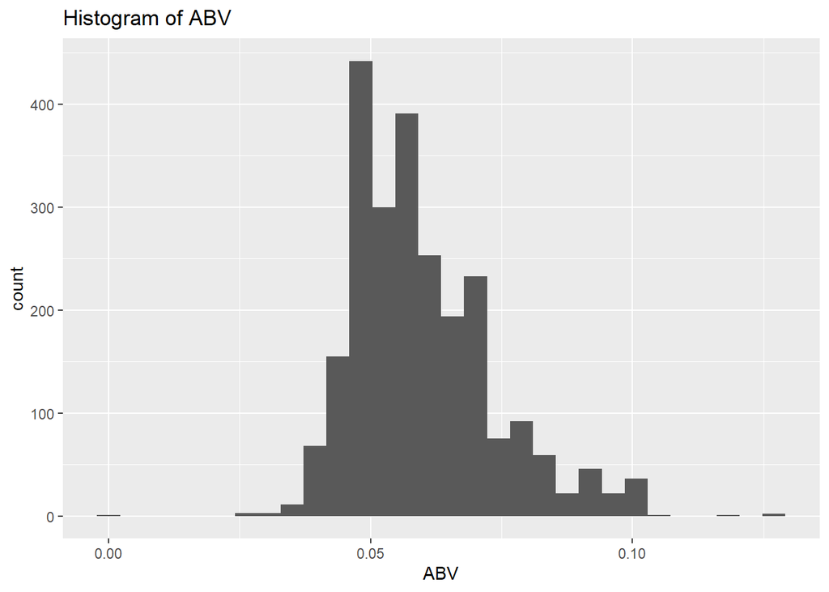

```r
beer_breweries %>%
  ggplot(aes(x=ABV)) +
  geom_histogram() +
  ggtitle("Histogram of ABV")
```

#question 7: Is there a relationship between the bitterness of the beer and its alcoholic content?

There seems to be a positive correlation between ABV and IBU. So that means there is a positive relationship betwen ABV and IBU so as ABV increases, so does IBU.

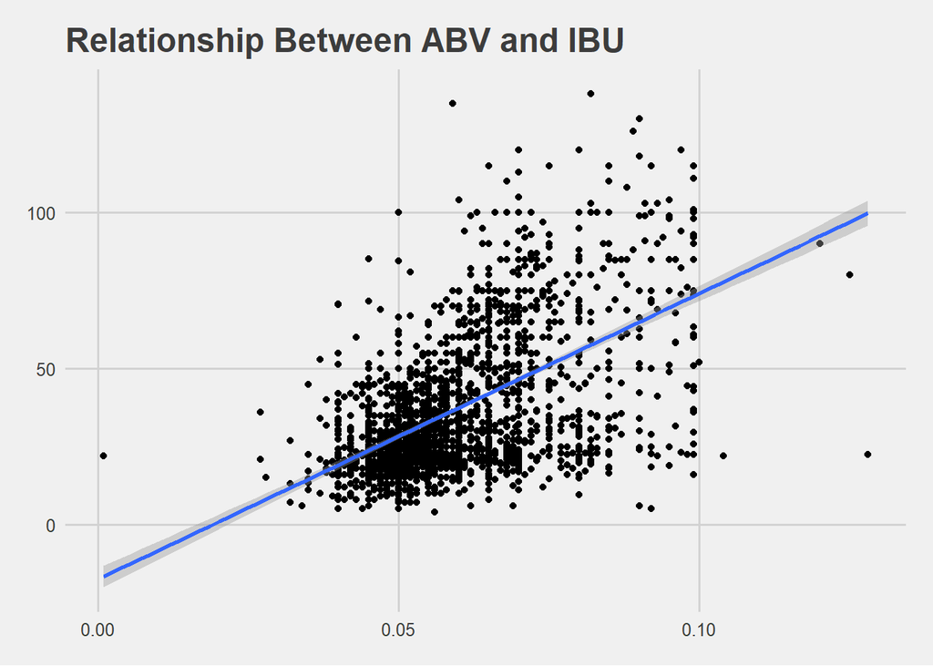

```r
#Plot a scatterplot comparing the two variables ABV and IBU with a regression line
beer_breweries %>% ggplot(aes(x=ABV,y=IBU)) + theme_fivethirtyeight() + geom_point()+geom_smooth(method=lm) +
  xlab("Alcohol By Volume (ABV)") +
  ylab("International Bitterness Unit (IBU)") +
  ggtitle( "Relationship Between ABV and IBU")
```

```r
#Calculate the correlation betwen ABV and IBU
cor(beer_breweries$ABV,beer_breweries$IBU)
```

```
## [1] 0.5393128
```

#question 8: IPA vs Ale

```r
# We use Regex to find which style is an Ale and create a boolean column for that
summary(as.factor(beer_breweries$Style))
```

```
##                                                        Abbey Single Ale
##                                   5                                   2
##                             Altbier              American Adjunct Lager
##                                  13                                  18
##            American Amber / Red Ale          American Amber / Red Lager
##                                 133                                  29
##                 American Barleywine                  American Black Ale
##                                   3                                  36
##                 American Blonde Ale                  American Brown Ale
##                                 108                                  70
##             American Dark Wheat Ale      American Double / Imperial IPA
##                                   7                                 105
##  American Double / Imperial Pilsner    American Double / Imperial Stout
##                                   2                                   9
##           American India Pale Lager                        American IPA
##                                   3                                 424
##                American Malt Liquor             American Pale Ale (APA)
##                                   1                                 245
##                 American Pale Lager             American Pale Wheat Ale
##                                  39                                  97
##                    American Pilsner                     American Porter
##                                  25                                  68
##                      American Stout                 American Strong Ale
##                                  39                                  14
##                  American White IPA                   American Wild Ale
##                                  11                                   6
##                       Baltic Porter                    Belgian Dark Ale
##                                   6                                  11
##                         Belgian IPA                    Belgian Pale Ale
##                                  18                                  24
##             Belgian Strong Dark Ale             Belgian Strong Pale Ale
##                                   6                                   7
##                  Berliner Weissbier                     BiÃ¨re de Garde
##                                  11                                   7
##                                Bock                             Braggot
##                                   7                                   1
##      California Common / Steam Beer                          Chile Beer
##                                   6                                   3
##                               Cider                           Cream Ale
##                                  37                                  29
```

[output cut: 45 more lines]

```
##                                   3                                   2
##                          Roggenbier              Russian Imperial Stout
##                                   2                                  11
##                            Rye Beer              Saison / Farmhouse Ale
##                                  18                                  52
##                         Schwarzbier              Scotch Ale / Wee Heavy
##                                   9                                  15
##                        Scottish Ale                              Shandy
##                                  19                                   3
##                         Smoked Beer                              Tripel
##                                   1                                  11
##                        Vienna Lager                           Wheat Ale
##                                  20                                   1
##                       Winter Warmer                             Witbier
##                                  15                                  51
```

```r
beer_breweries$Style <- as.character(beer_breweries$Style)
beer_breweries$is_ale <- str_detect(beer_breweries$Style, "\\bAle\\b")
summary(beer_breweries$is_ale)
```

```
##    Mode   FALSE    TRUE
## logical    1434     976
```

```r
beer_breweries %>%
  filter(is_ale) %>%
  select(Style) %>%
  count(Style)
```

```
## # A tibble: 29 x 2
##    Style                        n
##    <chr>                    <int>
##  1 Abbey Single Ale             2
##  2 American Amber / Red Ale   133
##  3 American Black Ale          36
##  4 American Blonde Ale        108
##  5 American Brown Ale          70
##  6 American Dark Wheat Ale      7
##  7 American Pale Ale (APA)    245
##  8 American Pale Wheat Ale     97
##  9 American Strong Ale         14
## 10 American Wild Ale            6
## # ... with 19 more rows
```

```r
# We use Regex to find which style is an IPA and create a boolean column for that
beer_breweries$is_IPA <- str_detect(beer_breweries$Style, "\\bIPA\\b")
summary(beer_breweries$is_IPA)
```

```
##    Mode   FALSE    TRUE
## logical    1839     571
```

```r
beer_breweries %>%
  filter(is_IPA) %>%
  select(Style) %>%
  count(Style)
```

```
## # A tibble: 5 x 2
##   Style                              n
##   <chr>                          <int>
## 1 American Double / Imperial IPA   105
## 2 American IPA                     424
## 3 American White IPA                11
## 4 Belgian IPA                       18
## 5 English India Pale Ale (IPA)      13
```

```r
beer_breweries
```

[output not shown]

[output cut: 9629 more lines]

```r
#Based on the two previous columns we create a new column which labels the observations as IPA or Ale
for(i in 1:dim(beer_breweries)[1])
{
  if (beer_breweries$is_ale[i]=="TRUE"& beer_breweries$is_IPA[i]== "FALSE")
  {
    beer_breweries$IPA_Ale[i] <- "Ale"
  }
 else if (beer_breweries$is_IPA[i]=="TRUE" & beer_breweries$is_ale[i]=="FALSE")
  {
    beer_breweries$IPA_Ale[i] <- "IPA"
 }
  else
  {
    beer_breweries$IPA_Ale[i] <- "Other"
  }

}
beer_breweries
```

[output not shown]

[output cut: 9629 more lines]

#question 8 Pt. 2: Knn for IPA Vs. Ale

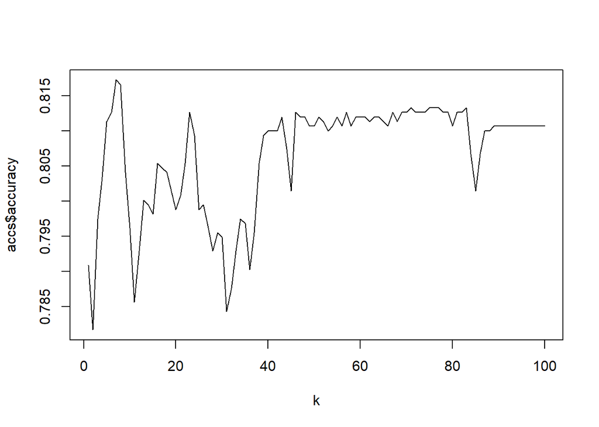

```r
# We do Knn where we loop for many K  and find the average accuracy with one training and test partion set

#Filter the classifications and then create the training set
beer_breweriesKnn<-beer_breweries %>% filter(IPA_Ale=="IPA"|IPA_Ale=="Ale")
set.seed(6)
splitPerc = .7
trainIndices = sample(1:dim(beer_breweriesKnn)[1],round(splitPerc * dim(beer_breweriesKnn)[1]))
train = beer_breweriesKnn[trainIndices,]
test = beer_breweriesKnn[-trainIndices,]
accs = data.frame(accuracy = numeric(100), k = numeric(100))

#Use Knn for when k = 1-100 and find the accuracy for each value of K
for(i in 1:100)
{
styles = knn.cv(beer_breweriesKnn[,c(7,8)],beer_breweriesKnn$IPA_Ale, prob = TRUE, k = i)
  table(beer_breweriesKnn$IPA_Ale,styles)
  CM = confusionMatrix(table(beer_breweriesKnn$IPA_Ale,styles))
  accs$accuracy[i] = CM$overall[1]
  accs$k[i] = i
}
#Plot the accuracy of of value of k
plot(accs$k,accs$accuracy, type = "l", xlab = "k")
```

```r
accu = accs$accuracy
max(accu)
```

```
## [1] 0.8172255
```

#question 8 Pt. 3: Knn with multiiple iterations for IPA Vs. Ale

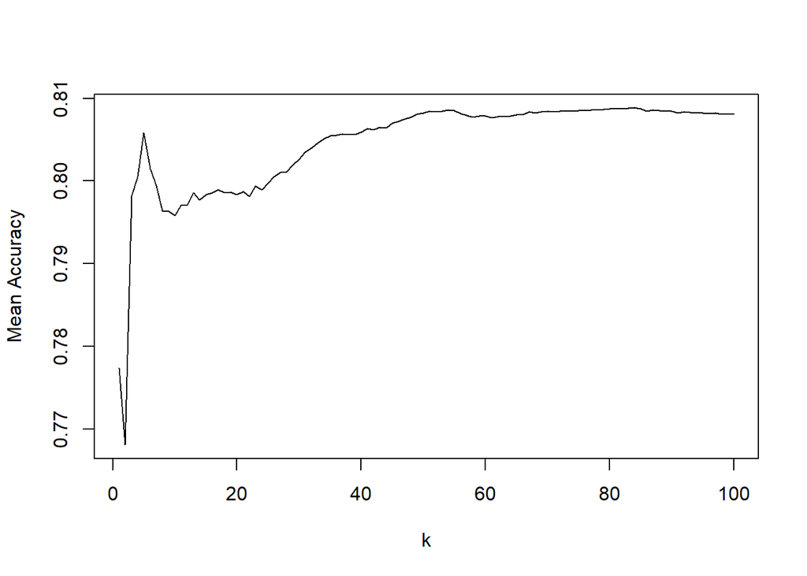

```r
# We loop for many K where we take the average accuracy of many training and partition sets

#Create 500 different iterations of training and test sets
iterations = 500
numks = 100

masterAcc = matrix(nrow = iterations, ncol = numks)

for(j in 1:iterations)
{
accs = data.frame(accuracy = numeric(100), k = numeric(100))
trainIndices = sample(1:dim(beer_breweriesKnn)[1],round(splitPerc * dim(beer_breweriesKnn)[1]))
train = beer_breweriesKnn[trainIndices,]
test = beer_breweriesKnn[-trainIndices,]

# Find the average accuracy with each iteration of the training and tests sets where k = 1-100
for(i in 1:numks)
{
  classifications = knn(train[,c(7,8)],test[,c(7,8)],train$IPA_Ale, prob = TRUE, k = i)
  table(classifications,test$IPA_Ale)
  CM = confusionMatrix(table(classifications,test$IPA_Ale))
  masterAcc[j,i] = CM$overall[1]
}

}

MeanAcc = colMeans(masterAcc)

#Plot the average accuracy of K
plot(seq(1,numks,1),MeanAcc, type = "l",xlab = "k",ylab = "Mean Accuracy")
```

```r
#Find the maximum average accuracy
max(MeanAcc)
```

```
## [1] 0.808864
```

#question 9: freeform EDA–most common word used in Beer_Names?

An interesting fact: in beer names, the most common words after the types of beers themselves are colors (red, blonde, brown), then “Wheat”, “Porter”, and “Summer”.

```r
#Look at beer names and remove duplicates
head(beer_breweries$Beer_Name)
```

```
## [1] Get Together  Maggie's Leap Wall's End    Pumpion       Stronghold
## [6] Parapet ESB
## 2305 Levels: #001 Golden Amber Lager ... Zonker Stout
```

```r
beer_breweries = beer_breweries %>%
  distinct(Beer_Name)

#put all the names into one big long string of words
Beer_Words = str_c(beer_breweries$Beer_Name, collapse = " ")
Beer_Words
```

```
## [1] "Get Together Maggie's Leap Wall's End Pumpion Stronghold Parapet ESB Citra Ass Down London Balling 35 K A Beer Rules are Rules Flesh Gourd'n Sho'nuff Bloody Show Rico Sauvin Coq de la Marche Kamen Knuddeln Pile of Face The Brown Note House Lager Leisure Time Excess IPL Hoponius Union Calyptr…
```

```r
#parse the individual words out into a data frame
Beer_words_distinct = str_match_all(Beer_Words, "(\\b\\w+\\b)")
head(Beer_words_distinct, 15)
```

```
## [[1]]
##         [,1]                [,2]
##    [1,] "Get"               "Get"
##    [2,] "Together"          "Together"
##    [3,] "Maggie"            "Maggie"
##    [4,] "s"                 "s"
##    [5,] "Leap"              "Leap"
##    [6,] "Wall"              "Wall"
##    [7,] "s"                 "s"
##    [8,] "End"               "End"
##    [9,] "Pumpion"           "Pumpion"
##   [10,] "Stronghold"        "Stronghold"
##   [11,] "Parapet"           "Parapet"
##   [12,] "ESB"               "ESB"
##   [13,] "Citra"             "Citra"
```

[output cut: 7060 more lines]

```r
Beer_words_df = data.frame(Beer_words_distinct)

#tally the count of each word
Beer_words_df %>%
  count(X1) %>%
  arrange(desc(n))
```

```
## # A tibble: 2,433 x 2
##    X1         n
##    <fct>  <int>
##  1 Ale      591
##  2 IPA      318
##  3 Pale     225
##  4 s        127
##  5 Lager    101
##  6 Amber     73
##  7 Stout     72
##  8 Red       61
##  9 Blonde    60
## 10 Brown     58
## # ... with 2,423 more rows
```